# HW 4

Jan Netík

#### 1.1.1

17

#### 1.1.2

3

#### 1.1.3

16

#### 1.1.4

17

#### 1.2.1

| položka | RIT |
| --- | --- |
| 3 | 0,44 |
| 16 | 0,49 |
| 17 | 0,17 |

Položky 3 a 16 souvisejí s celkovým skórem uspokojivě, položka 17 je problematická.

#### 1.2.2

| položka | RIR |
| --- | --- |
| 3 | 0,35 |
| 16 | 0,38 |
| 17 | 0,04 |

Ve všech případech korelace položky a celkového skóru bez dané položky klesla. RIR položky 17 není statisticky významně odlišný od nuly:

```r
data <- HCI[1:20]
cor.test(data[, 17], rowSums(data[-17]))
```

```
##
##  Pearson's product-moment correlation
##
## data:  data[, 17] and rowSums(data[-17])
## t = 1.1068, df = 649, p-value = 0.2688
## alternative hypothesis: true correlation is not equal to 0
## 95 percent confidence interval:
##  -0.03355071  0.11984721
## sample estimates:
##        cor
## 0.04340407
```

```r
rSquare <- cor.test(data[, 17], rowSums(data[-17]))$est^2
```

A se zbytkem testu sdílí položka pouze $1.88\ ‰$ variance.

#### 1.2.3

| položka | $\alpha$ drop |
| --- | --- |
| 3 | 0,70 |
| 16 | 0,70 |
| 17 | 0,73 |

Při srovnání s Cronbachovou $\alpha$ celého testu (viz následující box) je patrné, že položka 17 *snižuje* jeho reliabilitu.

```r
psychometric::alpha(data)
```

```
## [1] 0.7154535
```

#### 1.3.1

Teoreticky by se měly ULI položek *zvětšit*, protože porovnáváme rozdílnější („vzdálenější“) skupiny respondentů, než v případě srovnání 1. a 3. třetiny.

```r
uliComparison <- data.frame(five = gDiscrim(data, 5, 1, 5), three = gDiscrim(data, 3, 1, 3))

uliComparison %>% pander()
```

|  | five | three |
| --- | --- | --- |
| **Item 1** | 0.5 | 0.4194 |
| **Item 2** | 0.4308 | 0.3041 |
| **Item 3** | 0.4 | 0.3272 |
| **Item 4** | 0.4538 | 0.3088 |
| **Item 5** | 0.5385 | 0.4562 |
| **Item 6** | 0.5923 | 0.5069 |
| **Item 7** | 0.4077 | 0.235 |
| **Item 8** | 0.5538 | 0.447 |
| **Item 9** | 0.5154 | 0.3548 |
| **Item 10** | 0.4692 | 0.4608 |
| **Item 11** | 0.4538 | 0.3318 |
| **Item 12** | 0.6 | 0.4793 |
| **Item 13** | 0.6154 | 0.5438 |
| **Item 14** | 0.5077 | 0.4378 |
| **Item 15** | 0.5923 | 0.4885 |
| **Item 16** | 0.6385 | 0.5576 |
| **Item 17** | 0.2846 | 0.1659 |
| **Item 18** | 0.5692 | 0.4286 |
| **Item 19** | 0.5923 | 0.4147 |
| **Item 20** | 0.5308 | 0.4562 |

```r
wilcox.test(uliComparison$five, uliComparison$three, paired = T, alternative = "greater")
```

```
##
##  Wilcoxon signed rank test
##
## data:  uliComparison$five and uliComparison$three
## V = 210, p-value = 9.537e-07
## alternative hypothesis: true location shift is greater than 0
```

Jak je patrné z tabulky i Wilcoxonova testu, teoretický předpoklad zmíněný výše se potvrzuje.

#### 1.3.2

Teoreticky by se měly ULI položek *zmenšit*, protože porovnáváme podobnější („bližší“) skupiny respondentů, než v případě srovnání 1. a 5. pětiny.

```r
uliComparison2 <- data.frame(fourToFive = gDiscrim(data, 5, 4, 5), oneToFive = gDiscrim(data, 5, 1, 5) )

uliComparison2 %>% pander()
```

|  | fourToFive | oneToFive |
| --- | --- | --- |
| **Item 1** | 0.07692 | 0.5 |
| **Item 2** | 0.07692 | 0.4308 |
| **Item 3** | 0.01538 | 0.4 |
| **Item 4** | 0.2769 | 0.4538 |
| **Item 5** | 0.1923 | 0.5385 |
| **Item 6** | 0.1538 | 0.5923 |
| **Item 7** | 0.1923 | 0.4077 |
| **Item 8** | 0.1231 | 0.5538 |
| **Item 9** | 0.3 | 0.5154 |
| **Item 10** | 0.1538 | 0.4692 |
| **Item 11** | 0.06923 | 0.4538 |
| **Item 12** | 0.1385 | 0.6 |
| **Item 13** | 0.1154 | 0.6154 |
| **Item 14** | 0.03077 | 0.5077 |
| **Item 15** | 0.2308 | 0.5923 |
| **Item 16** | 0.07692 | 0.6385 |
| **Item 17** | 0.2462 | 0.2846 |
| **Item 18** | 0.02308 | 0.5692 |
| **Item 19** | 0.05385 | 0.5923 |
| **Item 20** | 0.08462 | 0.5308 |

```r
wilcox.test(uliComparison2$fourToFive, uliComparison2$oneToFive, paired = T, alternative = "less")
```

```
##
##  Wilcoxon signed rank test
##
## data:  uliComparison2$fourToFive and uliComparison2$oneToFive
## V = 0, p-value = 9.537e-07
## alternative hypothesis: true location shift is less than 0
```

#### 1.3.3

Porovnání 4. a 5. pětiny je vhodné při výběru položek diskriminujících skupinu respondentů s vysokou úrovní měřeného atributu (např. přijímací zkoušky s relativně nízkou úspěšností). Naopak porovnání 1. a 5. pětiny je žádoucí pro velmi nehomogenní skupinu respondentů (např. z obecné populace).

#### 1.3.4

```r
uliRows <- unname(
  rbind(
    gDiscrim(data, 5, 1, 2)[c(7, 17, 18)],
    gDiscrim(data, 5, 1, 3)[c(7, 17, 18)],
    gDiscrim(data, 5, 1, 4)[c(7, 17, 18)],
    gDiscrim(data, 5, 1, 5)[c(7, 17, 18)],
    gDiscrim(data, 5, 2, 5)[c(7, 17, 18)],
    gDiscrim(data, 5, 3, 5)[c(7, 17, 18)],
    gDiscrim(data, 5, 4, 5)[c(7, 17, 18)]
  )
)

uliTable <-
  tibble(
    groupsToCompare = c(
      "1st & 2nd",
      "1st & 3rd",
      "1st & 4th",
      "1st & 5th",
      "2nd & 5th",
      "3rd & 5th",
      "4th & 5th"
    ),
    "item7" = uliRows[, 1],
    "item17" = uliRows[, 2],
    "item18" = uliRows[, 3]
  )

pander(uliTable, digits = 2)
```

| groupsToCompare | item7 | item17 | item18 |
| --- | --- | --- | --- |
| 1st & 2nd | 0.25 | 0.077 | 0.36 |
| 1st & 3rd | 0.25 | 0.0077 | 0.48 |
| 1st & 4th | 0.22 | 0.038 | 0.55 |
| 1st & 5th | 0.41 | 0.28 | 0.57 |
| 2nd & 5th | 0.16 | 0.21 | 0.21 |
| 3rd & 5th | 0.15 | 0.28 | 0.092 |
| 4th & 5th | 0.19 | 0.25 | 0.023 |

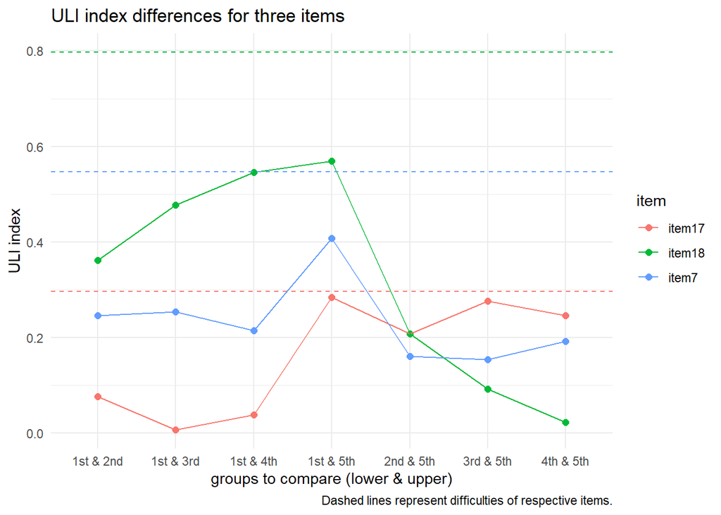

```r
difficulty <- ItemAnalysis(data)[c(7, 17, 18), 1]

pivot_longer(uliTable, cols = 2:4) %>%
  ggplot(aes(x = groupsToCompare, y = value, col = name)) +
  geom_point(size = 2) + geom_line(aes(group = name)) +
  geom_hline(yintercept = difficulty[1], col = "#619cff", linetype = "dashed") +
  geom_hline(yintercept = difficulty[2], col = "#f8766d", linetype = "dashed") +
  geom_hline(yintercept = difficulty[3], col = "#00ba38", linetype = "dashed") +
  labs(title = "ULI index differences for three items",
       caption = "Dashed lines represent difficulties of respective items.",
       x = "groups to compare (lower & upper)",
       y = "ULI index",
       col = "item") +
  theme_minimal()
```

Nejvyšších ULI dosahuje porovnání 1. a 5. pětin. Nízké hodnoty jsou naopak obvyklé u srovnání 3. a 5. a 4. a 5. pětiny, kde nadprůměrní respondenti v testu nevykazují velké rozdíly. ULI souvisí s obtížnostmni položek (v grafu šrafovaně) – nejobtížnější položka (17) velmi málo diskriminuje podpůrměrné respondenty. Zato nejjednoduší položka (18) dosahuje uspokojivých hodnot ULI u podprůměrných respondentů, horší je u vysoce nadprůměrných.

#### 2.1

Příkladem položky s dobře fungujícími distraktory je podle mého soudu položka 6. Nejhorší pětina respondentů zde nejvíce volí distraktor „B“ a správná odpověď se těší nejmenší „popularitě“. Naopak Nejlepší pětian respondentů nejčastěji odpovídá správně a distraktory volí relativně méně často. Distraktor „A“ je také monotónně klesající (v daném výběrovém souboru), navíc patrně mate nejhorší respondenty. Chování distraktoru „B“ je patrně způsobeno zdánlivě smysluplným obsahem a zkušeností z běžného života. Pokud však respondent dobře chápe koncept homeostázy, zapojí ho do svého uvažování a velmi pravděpodobně zvolí správnou odpověď, která obsahuje přesné zdůvodnění z hlediska homeostázy:

> 6. Normal body temperature of a healthy adult is about 37 degrees C. A fever occurs when the temperature set-point is elevated. Jasmine feels cold as she develops a fever because her body temperature at that time is
>    1. less than 37 degrees C.
>    2. increasing above 37 degrees C.
>    3. **less than the new set point temperature.**

Příkladem špatně fungujících distraktorů je naopak položka 17, která vykazuje obecně špatné psychometrické vlastnosti. Správná odpověď zde není monotónně rostoucí, a pouze distraktor „B“ je pro nejhorší pětinu výrazněji lákavější než správná odpověď. Druhá pětina respondentů volila všechny 4 odpovědi podobně často, což vypadá jako hádání. Položka je buď extrémně obtížná, nebo špatně formulovaná. Zdá se, že oproti jiným otázkám je v tomto případě nutné mít povědomí o tom, jaká je *povaha signálu z baroreceptorů* – pokud je TK nízký, vysílají baroreceptory větší/četnější signál, nebo je tomu naopak. Domnívám se, že pokud by tato informace byla ve znení položky, dopadla by mnohem lépe (jak je patrné i z grafu níže, až vysoce nadprůměrní respondenti, kteří pravděpodobněji zmíněnou informaci znají, odpovídali častěji správně)[^1].

> 17. Baroreceptors sense blood pressure. The baroreceptor nerves are cut so the signal from the baroreceptors is unable to reach the cardiovascular control center. After cutting the nerves, blood pressure will
>     1. remain constant.
>     2. decrease.
>     3. **increase.**
>     4. become equal to the set-point value.

#### 3.1.1

Již načteno pomocí `library(ShinyItemAnalysis)`.

#### 3.1.2

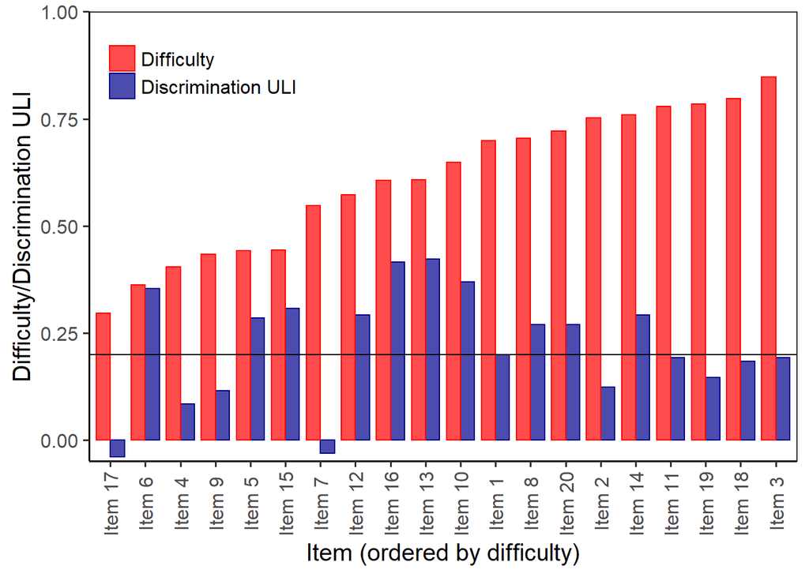

```r
DDplot(data, k = 5, l = 2, u = 4)
```

#### 3.1.3

```r
ItemAnalysis(data, k = 5, l = 2, u = 4) %>%
  select(-"Item validity", -"Item criterion") %>% # exclude irrelevant indices
  pander(digits = 2)
```

Table continues below

|  | Difficulty | Average score | SD | Min score | Max score |
| --- | --- | --- | --- | --- | --- |
| **Item 1** | 0.7 | 0.7 | 0.46 | 0 | 1 |
| **Item 2** | 0.75 | 0.75 | 0.43 | 0 | 1 |
| **Item 3** | 0.85 | 0.85 | 0.36 | 0 | 1 |
| **Item 4** | 0.4 | 0.4 | 0.49 | 0 | 1 |
| **Item 5** | 0.44 | 0.44 | 0.5 | 0 | 1 |
| **Item 6** | 0.36 | 0.36 | 0.48 | 0 | 1 |
| **Item 7** | 0.55 | 0.55 | 0.5 | 0 | 1 |
| **Item 8** | 0.71 | 0.71 | 0.46 | 0 | 1 |
| **Item 9** | 0.43 | 0.43 | 0.5 | 0 | 1 |
| **Item 10** | 0.65 | 0.65 | 0.48 | 0 | 1 |
| **Item 11** | 0.78 | 0.78 | 0.42 | 0 | 1 |
| **Item 12** | 0.57 | 0.57 | 0.5 | 0 | 1 |
| **Item 13** | 0.61 | 0.61 | 0.49 | 0 | 1 |
| **Item 14** | 0.76 | 0.76 | 0.43 | 0 | 1 |
| **Item 15** | 0.44 | 0.44 | 0.5 | 0 | 1 |
| **Item 16** | 0.61 | 0.61 | 0.49 | 0 | 1 |
| **Item 17** | 0.3 | 0.3 | 0.46 | 0 | 1 |
| **Item 18** | 0.8 | 0.8 | 0.4 | 0 | 1 |
| **Item 19** | 0.78 | 0.78 | 0.41 | 0 | 1 |
| **Item 20** | 0.72 | 0.72 | 0.45 | 0 | 1 |

Table continues below

|  | Obtained min | Obtained max | Cut score | ULI | ULI default |
| --- | --- | --- | --- | --- | --- |
| **Item 1** | 0 | 1 | 1 | 0.2 | 0.42 |
| **Item 2** | 0 | 1 | 1 | 0.12 | 0.3 |
| **Item 3** | 0 | 1 | 1 | 0.19 | 0.33 |
| **Item 4** | 0 | 1 | 1 | 0.085 | 0.31 |
| **Item 5** | 0 | 1 | 1 | 0.28 | 0.46 |
| **Item 6** | 0 | 1 | 1 | 0.35 | 0.51 |
| **Item 7** | 0 | 1 | 1 | -0.031 | 0.24 |
| **Item 8** | 0 | 1 | 1 | 0.27 | 0.45 |
| **Item 9** | 0 | 1 | 1 | 0.12 | 0.35 |
| **Item 10** | 0 | 1 | 1 | 0.37 | 0.46 |
| **Item 11** | 0 | 1 | 1 | 0.19 | 0.33 |
| **Item 12** | 0 | 1 | 1 | 0.29 | 0.48 |
| **Item 13** | 0 | 1 | 1 | 0.42 | 0.54 |
| **Item 14** | 0 | 1 | 1 | 0.29 | 0.44 |
| **Item 15** | 0 | 1 | 1 | 0.31 | 0.49 |
| **Item 16** | 0 | 1 | 1 | 0.42 | 0.56 |
| **Item 17** | 0 | 1 | 1 | -0.038 | 0.17 |
| **Item 18** | 0 | 1 | 1 | 0.18 | 0.43 |
| **Item 19** | 0 | 1 | 1 | 0.15 | 0.41 |
| **Item 20** | 0 | 1 | 1 | 0.27 | 0.46 |

|  | RIT | RIR | Item reliability | Item reliability woi | Alpha drop |
| --- | --- | --- | --- | --- | --- |
| **Item 1** | 0.4 | 0.29 | 0.18 | 0.13 | 0.7 |
| **Item 2** | 0.33 | 0.22 | 0.14 | 0.095 | 0.71 |
| **Item 3** | 0.44 | 0.35 | 0.16 | 0.13 | 0.7 |
| **Item 4** | 0.3 | 0.17 | 0.15 | 0.085 | 0.72 |
| **Item 5** | 0.4 | 0.28 | 0.2 | 0.14 | 0.71 |
| **Item 6** | 0.46 | 0.34 | 0.22 | 0.16 | 0.7 |
| **Item 7** | 0.24 | 0.1 | 0.12 | 0.05 | 0.72 |
| **Item 8** | 0.44 | 0.33 | 0.2 | 0.15 | 0.7 |
| **Item 9** | 0.34 | 0.21 | 0.17 | 0.11 | 0.71 |
| **Item 10** | 0.38 | 0.26 | 0.18 | 0.13 | 0.71 |
| **Item 11** | 0.39 | 0.29 | 0.16 | 0.12 | 0.7 |
| **Item 12** | 0.44 | 0.32 | 0.22 | 0.16 | 0.7 |
| **Item 13** | 0.48 | 0.36 | 0.23 | 0.18 | 0.7 |
| **Item 14** | 0.44 | 0.34 | 0.19 | 0.14 | 0.7 |
| **Item 15** | 0.42 | 0.3 | 0.21 | 0.15 | 0.7 |
| **Item 16** | 0.49 | 0.38 | 0.24 | 0.19 | 0.7 |
| **Item 17** | 0.17 | 0.043 | 0.077 | 0.02 | 0.73 |
| **Item 18** | 0.51 | 0.42 | 0.2 | 0.17 | 0.69 |
| **Item 19** | 0.46 | 0.37 | 0.19 | 0.15 | 0.7 |
| **Item 20** | 0.45 | 0.34 | 0.2 | 0.15 | 0.7 |

#### 3.1.4

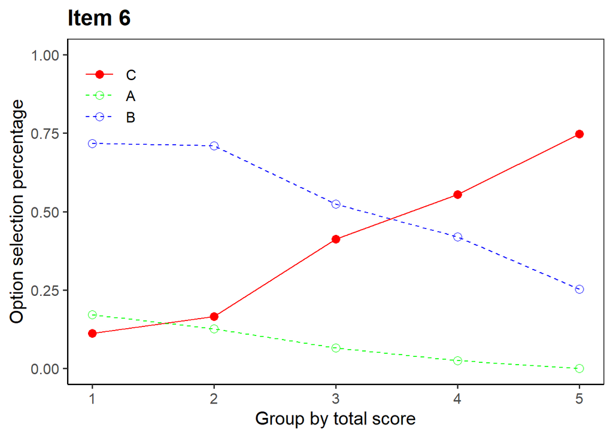

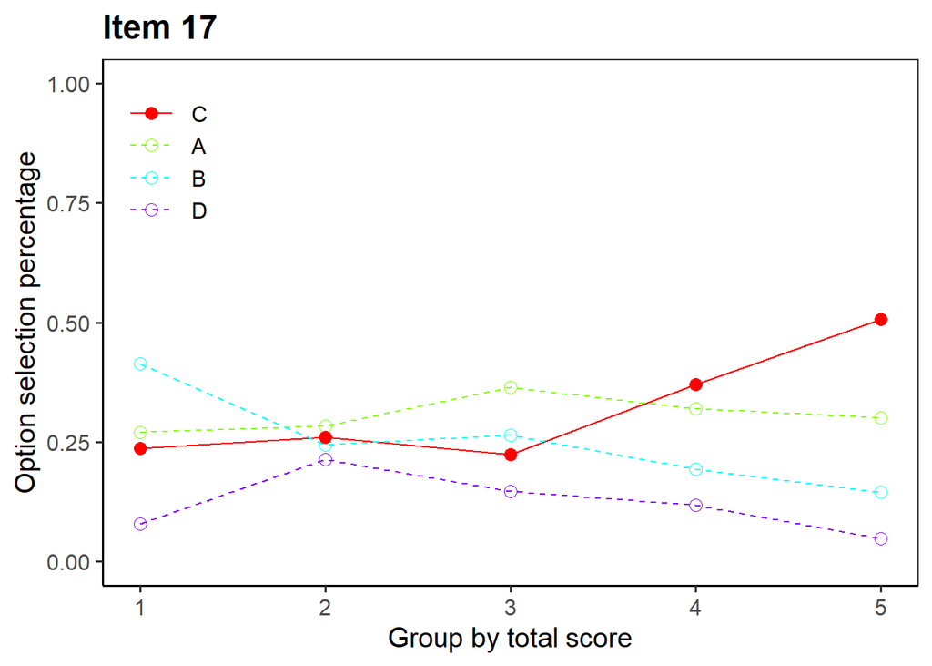

```r
for (i in c(6,17)) {
 print(plotDistractorAnalysis(HCItest[, 1:20], key = HCIkey, num.groups = 5, item = i))
}
```

#### 4

Tentokrát jsem nic, kromě pár překlepů, nenašel :-)

[^1]: Mimochodem dobrým validačním kritériem HCI by mohla být přítomnost/nepřítomnost nějakého endokrinologického onemocnění, kde se silně uplatňuje homeostáza – např. pacienti s thyreopatií dobře vědí, že deplece hormonů štítné žlázy vede k nadměrné produkci thyreostimulační hormonu adenohypofýzou